# Moreen

2023-07-12

```r
# Load required packages
library(dplyr)
```

```r
library(ggplot2)
library(tidyr)
library(forecast)
library(tidyverse)
library(tidymodels)
library(GGally)
library(broom)
```

## Loading data and data exploration

```r
inventory_data <- readr::read_csv("data/inventory.csv")
# Summary statistics
summary(inventory_data)
```

```
##    item_no               week           sold
##  Length:26352       Min.   : 0.0   Min.   :   0.00
##  Class :character   1st Qu.:13.0   1st Qu.:   0.00
##  Mode  :character   Median :26.5   Median :   0.00
##                     Mean   :26.5   Mean   :  50.62
##                     3rd Qu.:40.0   3rd Qu.:   2.00
##                     Max.   :53.0   Max.   :7200.00
```

```r
# Explore the structure of the data
str(inventory_data)
```

```
## spc_tbl_ [26,352 × 3] (S3: spec_tbl_df/tbl_df/tbl/data.frame)
##  $ item_no: chr [1:26352] "020-307" "020-307" "020-307" "020-307" ...
##  $ week   : num [1:26352] 0 1 2 3 4 5 6 7 8 9 ...
##  $ sold   : num [1:26352] 0 80 0 0 0 0 0 0 80 0 ...
##  - attr(*, "spec")=
##   .. cols(
##   ..   item_no = col_character(),
##   ..   week = col_double(),
##   ..   sold = col_double()
##   .. )
##  - attr(*, "problems")=<externalptr>
```

The scatter plot shows whether the two variables are not correlated

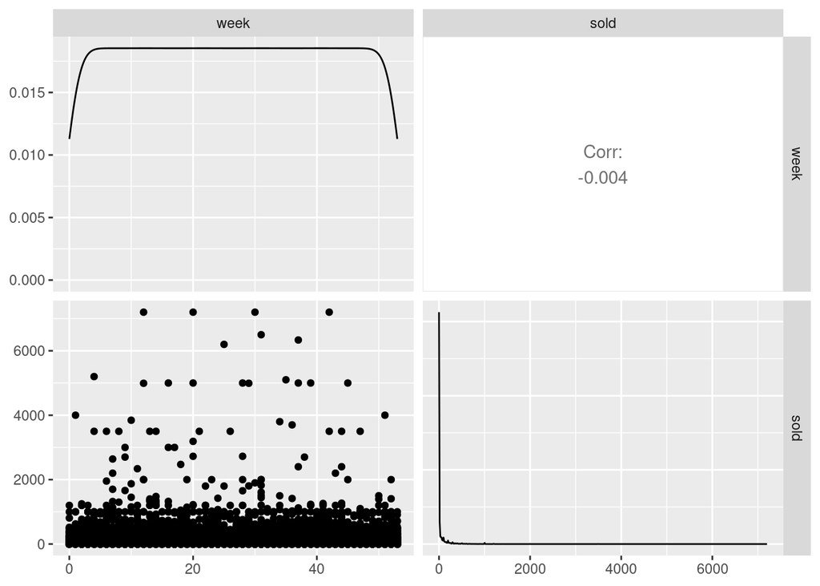

```r
inventory_data %>%
  select(week,sold) %>%
  ggpairs()
```

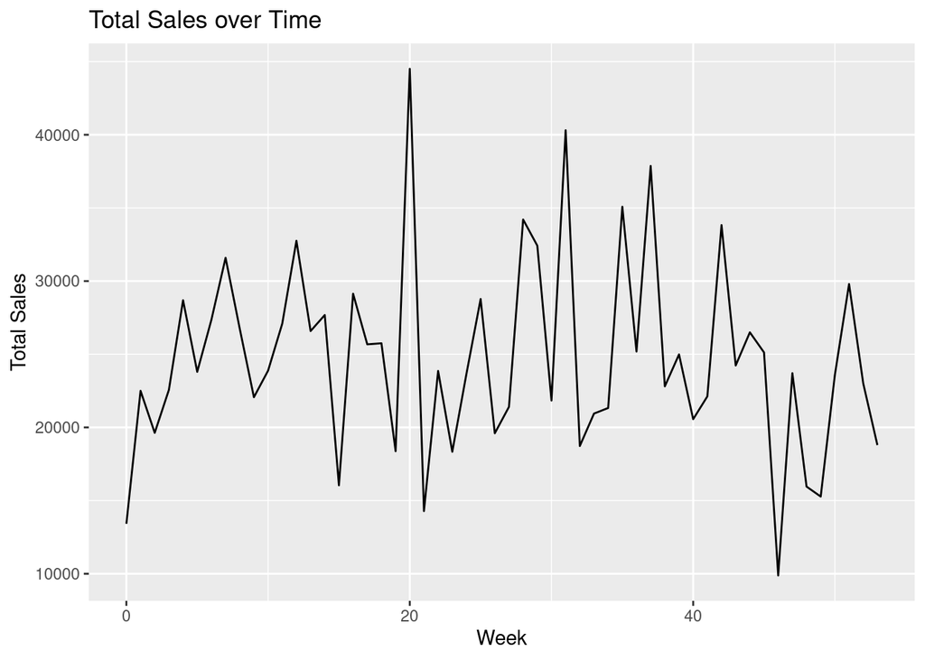

```r
# Create a time series plot of sales
inventory_ts <- inventory_data %>%
  group_by(week) %>%
  summarise(total_sales = sum(sold))

ggplot(inventory_ts, aes(x = week, y = total_sales)) +
  geom_line() +
  xlab("Week") +
  ylab("Total Sales") +
  ggtitle("Total Sales over Time")
```

**Analysis of the response variable**

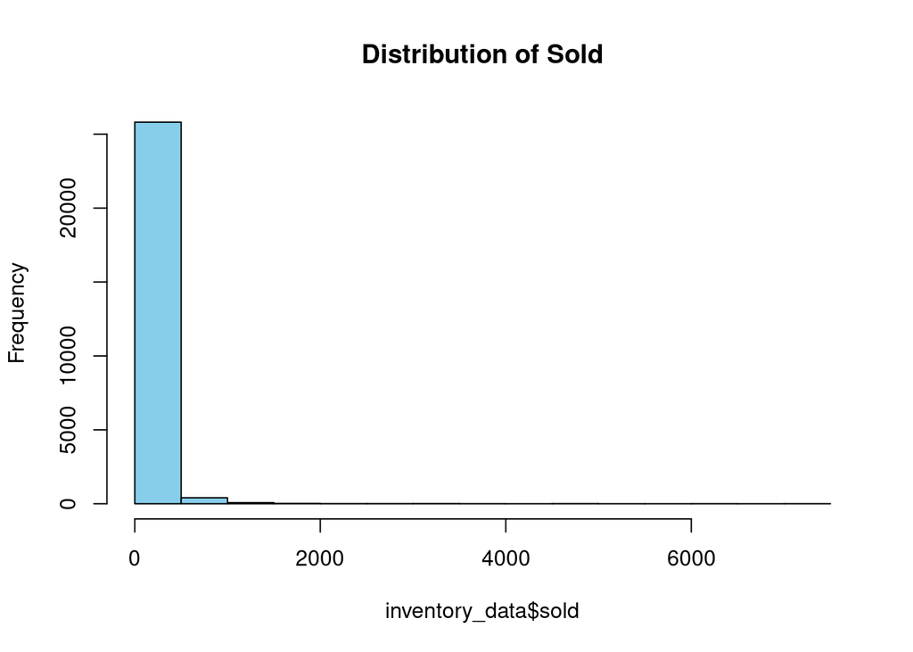

```r
# Histogram of sold variable
hist(inventory_data$sold, breaks = 20, col = "skyblue", main = "Distribution of Sold")
```

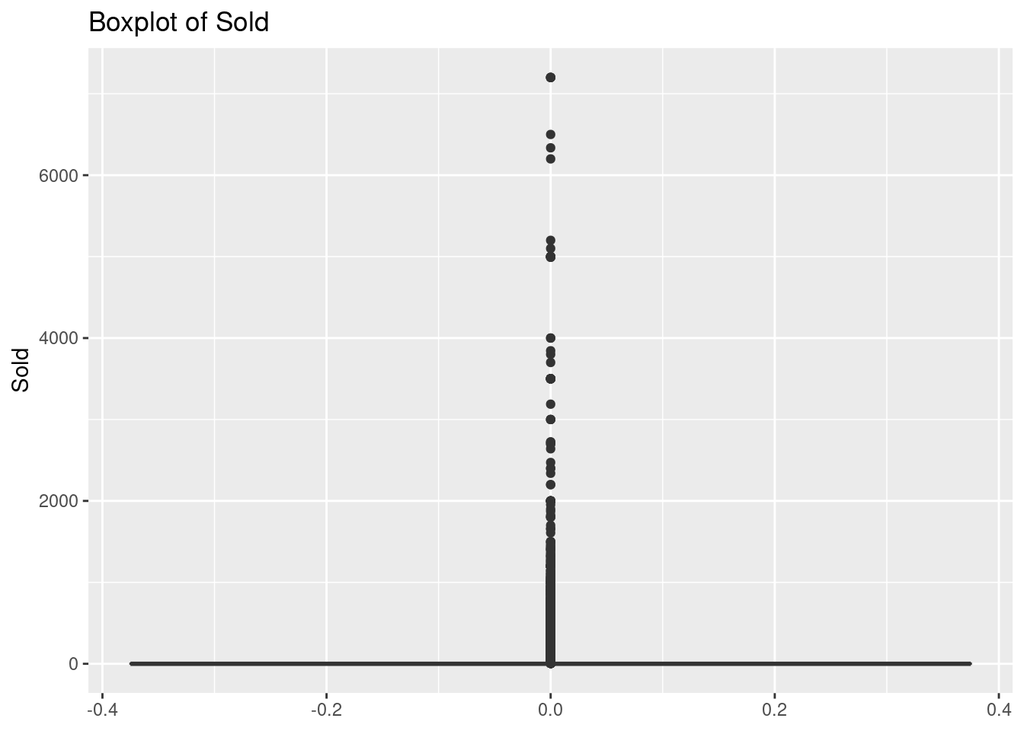

```r
# Create a box plot of sold variable
ggplot(inventory_data, aes(y = sold)) +
  geom_boxplot(fill = "skyblue") +
  labs(y = "Sold", title = "Boxplot of Sold")
```

## Data preparation

Select products for modeling:

```r
# Filter products based on sales volume or other criteria
selected_products <- inventory_data %>%
  group_by(item_no) %>%
  summarise(total_sales = sum(sold)) %>%
  filter(total_sales > 1000) %>%
  pull(item_no)
```

## Fitting model

Next Fit a Poisson regression model for each selected product:

```r
# Function to fit Poisson regression model for a given product
fit_poisson <- function(data) {
  # Fit Poisson regression model
  poisson_model <- glm(sold ~ week, data = data, family = poisson)

  # Make predictions
  predicted_sales <- predict(poisson_model, type = "response")

  return(predicted_sales)
}

# Fit Poisson regression model and make predictions for each selected product
product_predictions <- lapply(selected_products, function(product) {
  product_data <- inventory_data %>%
    filter(item_no == product)

  fit_poisson(product_data)
})
```

In the code above, the fit_poisson() function is defined to fit a Poisson regression model using the glm() function from base R. It uses the “week” variable as the predictor for sales (“sold”) and specifies the family as Poisson.

The lapply() function is then used to apply the fit_poisson() function to each selected product, resulting in a list of predicted sales values for each product.

## Model evaluation

Finally evaluate the goodness of predictions:

```r
# Evaluate the goodness of predictions
evaluate_predictions <- function(product, prediction_data) {
  actual_data <- inventory_data %>%
    filter(item_no == product)

  # Calculate metrics (e.g., MAE)
  mae <- mean(abs(actual_data$sold - prediction_data))

  return(mae)
}

# Evaluate the goodness of predictions for each selected product
evaluation_results <- lapply(1:length(selected_products), function(i) {
  product <- selected_products[i]
  prediction_data <- product_predictions[[i]]

  evaluate_predictions(product, prediction_data)
})

# Calculate overall performance metric (e.g., average MAE)
overall_performance <- mean(unlist(evaluation_results))
overall_performance
```

```
## [1] 101.8706
```

The evaluate_predictions() function is defined to calculate the MAE (Mean Absolute Error) between the actual sales data and predicted sales values for a specific product. The lapply() function is used to apply this function to each product and store the results.

Finally, an overall performance metric (e.g., average MAE) is calculated by averaging the individual evaluation results.

```r
# Create a new data frame to store the aggregated inventory needs
inventory_needs <- data.frame(
  week = numeric(),
  inventory_needed = numeric(),
  number_of_items_needed = integer(),  # Changed to integer type
  stringsAsFactors = FALSE
)

# Iterate over each selected product
for (i in 1:length(selected_products)) {
  product <- selected_products[i]
  prediction_data <- product_predictions[[i]]

  # Calculate monthly inventory needs
  monthly_needs <- aggregate(prediction_data, by = list(week = rep(1:12, length.out = length(prediction_data))), FUN = sum)

  # Add product and month information to the data frame
  monthly_needs$product <- product
  monthly_needs$month <- 1:12

  # Rename the aggregated column to "inventory_needed"
  names(monthly_needs)[3] <- "inventory_needed"

  # Convert "x" column to integer and remove decimals
  monthly_needs$number_of_items_needed <- as.integer(monthly_needs$x)

  # Remove the original "x" column
  monthly_needs$x <- NULL

  # Append the monthly inventory needs to the main data frame
  inventory_needs <- rbind(inventory_needs, monthly_needs)
}
```

Creating a csv output of monthly inventory needs per product

```r
# Export the inventory needs data to a CSV file
#write.csv(inventory_needs, "inventory_needs_monthly.csv", row.names = FALSE)
write.csv(inventory_needs[c("week", "inventory_needed", "number_of_items_needed")], file = "inventory_needs.csv", row.names = FALSE)
```